- **Title: Working example 2**
- **Output: html_document**
- **Reference: A guide to test association between Polygenic Risk Scores and psychological and psychiatric traits: practical examples**
- **Authors: Itziar Irigoien, Patricia Mas, Araceli Rosa, and Concepción Arenas**

## Working example 2

### In this example we simulate 10 PRSs, and a continuous trait, with gender, clinical diagnosis (with 2 categories), age, and two Principal Components as covariates.

- **data reading**

```r
dat <- read.table("WExample2.csv", header=TRUE, sep=";", dec=",")
names(dat) #
```

```
##  [1] "Diagnostic" "Sex"        "Age"        "Trait"      "PRS.1"
##  [6] "PRS.2"      "PRS.3"      "PRS.4"      "PRS.5"      "PRS.6"
## [11] "PRS.7"      "PRS.8"      "PRS.9"      "PRS.10"     "PC1"
## [16] "PC2"
```

- **do not forget to declare the categorical variables as factors**

```r
dat$Sex <- as.factor(dat$Sex)
dat$Diagnostic <- as.factor(dat$Diagnostic)
```

- **Step 1: Order the PRSs**

```r
out <- orderR2(dat, yname="Trait", prsname = "PRS.")
head(out)
```

```
##            Model1     Model2    Model3    Model4       Sum
## PRS.5  0.06590991 0.14386357 0.1167506 0.1730818 0.4996059
## PRS.10 0.04263225 0.05908320 0.1400714 0.1838914 0.4256782
## PRS.8  0.05330296 0.07034766 0.1239488 0.1626609 0.4102603
## PRS.2  0.06157642 0.06212837 0.1293514 0.1294614 0.3825176
## PRS.9  0.03691860 0.07445585 0.1061419 0.1443078 0.3618242
## PRS.1  0.06250443 0.06260526 0.1138417 0.1140869 0.3530384
```

```r
mainfilename <- "WExample2"
filename <- paste0(mainfilename, "_Ordered_PRS.csv")
write.csv2(out,file=filename)
```

- **Step 1: Plot the sum of coefficients of determination $S_{R^2}$. Lines: in blue the median; in black the mean**

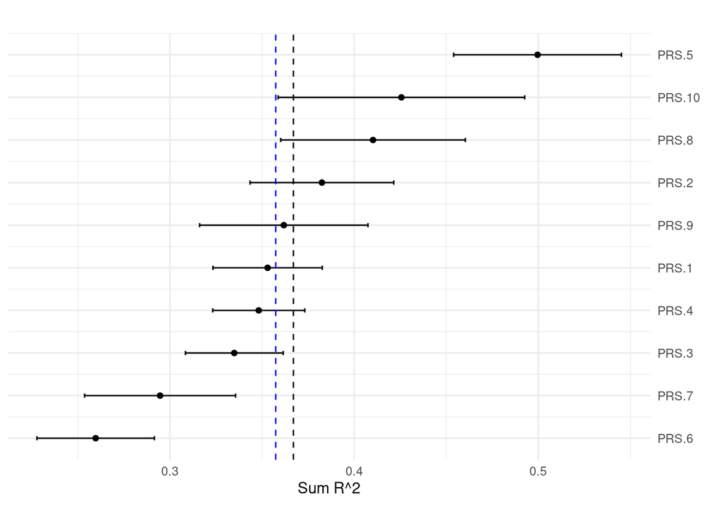

```r
out <- data.frame(out)
n <- dim(out)[1]
select <- grep("Model", names(out), value=FALSE)
out$effect <- out$Sum
sds <- apply(out[, select], 1, sd)
out$lower <- out$effect - sds
out$upper <- out$effect + sds
out$rank <- n:1


ggplot(data=out, aes(y=rank, x=effect, xmin=lower, xmax=upper)) +
  geom_point() +
  geom_errorbarh(height=.1) +
  scale_y_continuous(name=NULL, breaks= n:1, labels=row.names(out), position="right") +
  labs(title='', x='Sum R^2', y = 'PRS') +
  geom_vline(xintercept=mean(out$effect), color='black', linetype='dashed') +
  geom_vline(xintercept=median(out$effect), color='blue', linetype='dashed') +
  theme_minimal()
```

- **Repeat the plot with only de PRS with $S_{R^2}$ larger then the median. Lines: in red and solid the 95% percentile; in red and dashed the 90%, 85%, 80% percentiles**

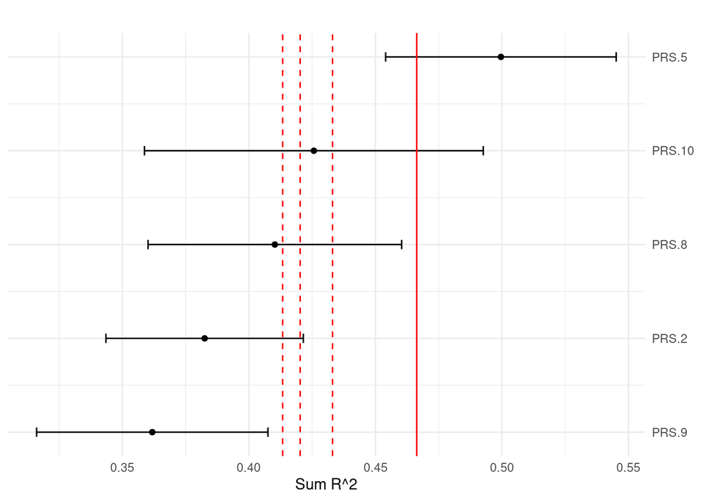

```r
sel <- out$Sum > median(out$effect)
ggplot(data=out[sel,], aes(y=rank, x=effect, xmin=lower, xmax=upper)) +
  geom_point() +
  geom_errorbarh(height=.1) +
  scale_y_continuous(name=NULL, breaks= n:1, labels=row.names(out), position="right") +
  labs(title='', x='Sum R^2', y = 'PRS') +
  geom_vline(xintercept=quantile(out$Sum, prob=0.95), color='red', linetype='solid') +
  geom_vline(xintercept=quantile(out$Sum, prob=c(0.80, 0.85, 0.90)), color='red', linetype='dashed') +
  theme_minimal()
```

- **Create files with PRS with the sum of $R^2$ greater then the 95%, 90%, 85% and 80% percentile**

```r
sel_95 <- out$Sum > quantile(out$Sum, prob=0.95)
write.csv2(out[sel_95,-9], file=paste0(mainfilename, "_Percentile_95.csv"))
sel_90 <- out$Sum > quantile(out$Sum, prob=0.90)
write.csv2(out[sel_90,-9], file=paste0(mainfilename, "_Percentile_90.csv"))
sel_85 <- out$Sum > quantile(out$Sum, prob=0.85)
write.csv2(out[sel_85,-9], file=paste0(mainfilename, "_Percentile_85.csv"))
sel_80 <- out$Sum > quantile(out$Sum, prob=0.80)
write.csv2(out[sel_80,-9], file=paste0(mainfilename, "_Percentile_80.csv"))
```

### According to the obtained results, first PRS.5 is selected to analyse its association with the Trait.

- **Step 2.1: Plots to check the possible interactions**

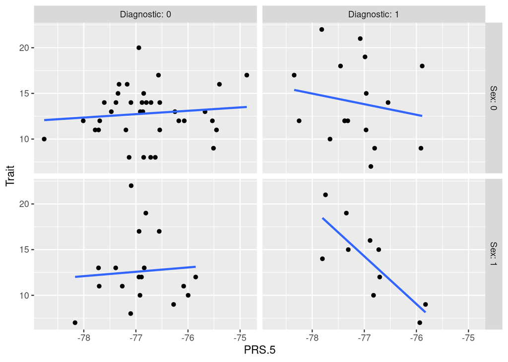

```r
ggplot(dat, aes(x=PRS.5, y=Trait)) +
  geom_point() +
  geom_smooth(method=lm, se=FALSE)+
  facet_grid(Sex ~ Diagnostic, labeller=label_both)
```

```r
# Candidate FM Trait ~ PRS + Sex + Diagnostic + PRS + PRS*Diagnostic + PC1 +PC2
```

### The plots suggest that the interaction between the PRS.5 and the diagnostic is relevant. Thus, we set the full model candidate (FM): $Trait \sim PRS + Sex + Diagnostic + Sex + PRS \cdot Diagnostic + PC1 +PC2$

- **Step2.2: Do parametric assumptions for the selected FM hold?**

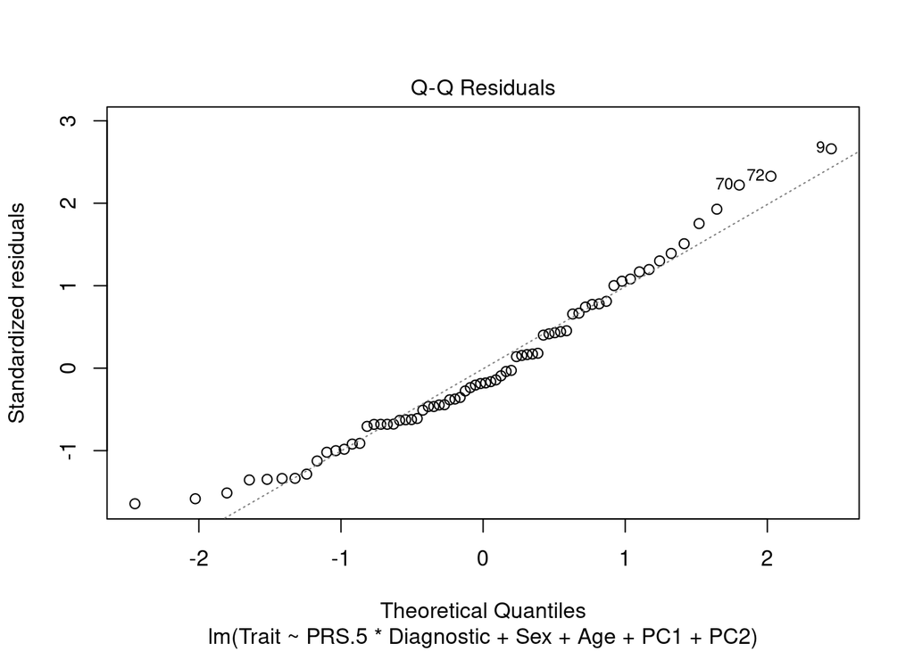

```r
#model
FM <- lm(Trait ~ PRS.5*Diagnostic + Sex + Age + PC1 + PC2, data=dat)
#qq-plot for normality
plot(FM,2)
```

### Lack of normality of residuals is suggested

```r
#Shapiro-Wilk test
shapiro.test(FM$residuals)
```

```
##
##  Shapiro-Wilk normality test
##
## data:  FM$residuals
## W = 0.96257, p-value = 0.03475
```

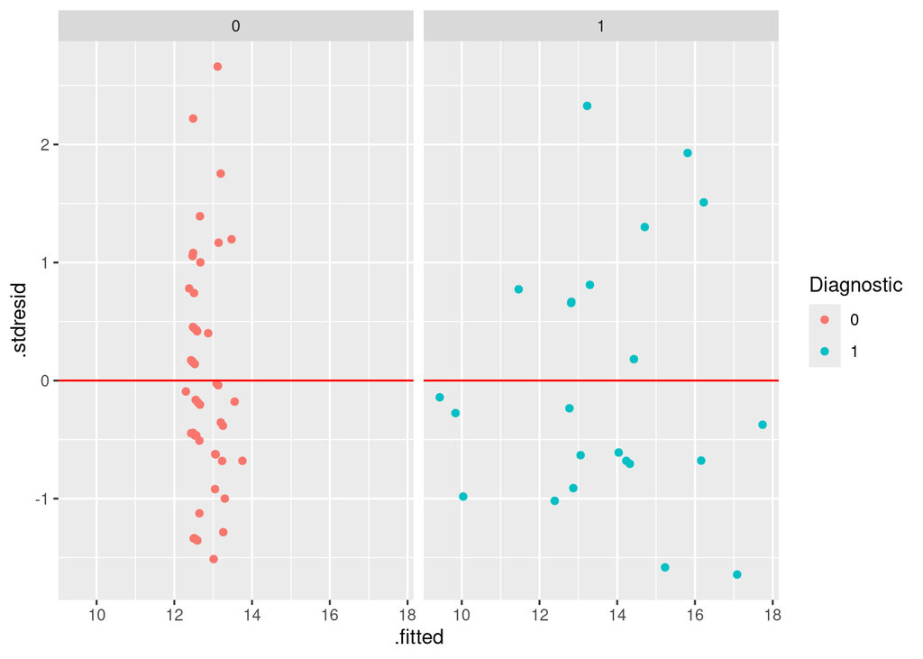

```r
#plot for variances
d <- fortify(FM)
ggplot(d,aes(x=.fitted, y=.stdresid, colour=Diagnostic)) + geom_point() + geom_hline(yintercept=0, col="red")+
  facet_wrap(.~Diagnostic)
```

```r
#Levene's test
leveneTest(.stdresid ~ Diagnostic, data=d)
```

```
## Levene's Test for Homogeneity of Variance (center = median)
##       Df F value Pr(>F)
## group  1  0.4042 0.5271
##       68
```

### It seems that there is lack of normality of residual but linearity and homocedasticity assumptions hold. Thus, we have two approaches to assess the possible association with PRS.5 and the Trait: try a transformation (**Step 4.1.1**) or perform a permutation test (**Step 4.1.2**)

- **Step 4.1.1: Try a transformation of the dependent variable:**

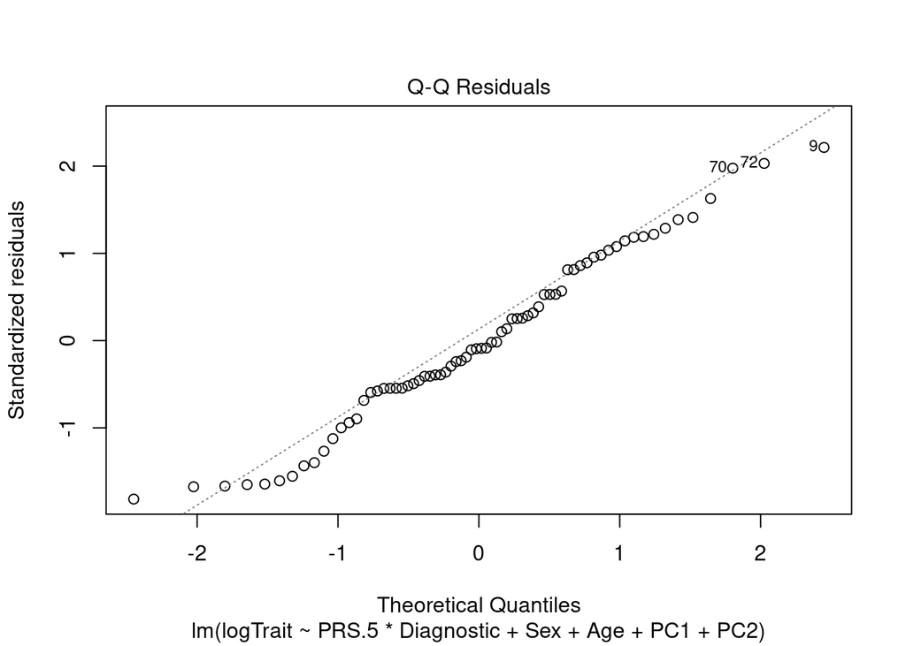

```r
dat$logTrait <- log(dat$Trait)
FM <- lm(logTrait ~ PRS.5*Diagnostic + Sex + Age + PC1 + PC2, data=dat)
#qq-plot for normality
plot(FM,2)
```

```r
#Shapiro-Wilk test
shapiro.test(FM$residuals)
```

```
##
##  Shapiro-Wilk normality test
##
## data:  FM$residuals
## W = 0.97729, p-value = 0.2331
```

### Since it is suggested the transformation offered a solution for the lack of normality, the model we build is given by:

```r
summary(FM)
```

```
##
## Call:
## lm(formula = logTrait ~ PRS.5 * Diagnostic + Sex + Age + PC1 +
##     PC2, data = dat)
##
## Residuals:
##      Min       1Q   Median       3Q      Max
## -0.44983 -0.13453 -0.02147  0.20389  0.55307
##
## Coefficients:
##                     Estimate Std. Error t value Pr(>|t|)
## (Intercept)        2.585e+00  4.118e+00   0.628   0.5325
## PRS.5              8.892e-04  5.365e-02   0.017   0.9868
## Diagnostic1       -2.005e+01  8.027e+00  -2.498   0.0152 *
## Sex1               4.141e-02  6.937e-02   0.597   0.5527
## Age               -6.155e-04  6.528e-03  -0.094   0.9252
## PC1                1.971e-01  4.669e-01   0.422   0.6744
## PC2               -5.958e-02  4.440e-01  -0.134   0.8937
## PRS.5:Diagnostic1 -2.607e-01  1.042e-01  -2.502   0.0150 *
## ---
## Signif. codes:  0 '***' 0.001 '**' 0.01 '*' 0.05 '.' 0.1 ' ' 1
##
## Residual standard error: 0.2581 on 62 degrees of freedom
##   (11 observations deleted due to missingness)
## Multiple R-squared:  0.1518, Adjusted R-squared:  0.05609
## F-statistic: 1.586 on 7 and 62 DF,  p-value: 0.1564
```

### The results show that PRS.5 is related with the log(Trait) in the following way:

- **Step 3: Check whether the respective PRS coefficients under each group are significant or not**

```r
summary(glht(FM, "PRS.5 = 0"))
```

```
##
##   Simultaneous Tests for General Linear Hypotheses
##
## Fit: lm(formula = logTrait ~ PRS.5 * Diagnostic + Sex + Age + PC1 +
##     PC2, data = dat)
##
## Linear Hypotheses:
##             Estimate Std. Error t value Pr(>|t|)
## PRS.5 == 0 0.0008892  0.0536465   0.017    0.987
## (Adjusted p values reported -- single-step method)
```

```r
summary(glht(FM, "PRS.5  + PRS.5:Diagnostic1 = 0"))
```

```
##
##   Simultaneous Tests for General Linear Hypotheses
##
## Fit: lm(formula = logTrait ~ PRS.5 * Diagnostic + Sex + Age + PC1 +
##     PC2, data = dat)
##
## Linear Hypotheses:
##                                Estimate Std. Error t value Pr(>|t|)
## PRS.5 + PRS.5:Diagnostic1 == 0 -0.25979    0.08808  -2.949  0.00449 **
## ---
## Signif. codes:  0 '***' 0.001 '**' 0.01 '*' 0.05 '.' 0.1 ' ' 1
## (Adjusted p values reported -- single-step method)
```

### That means that for Diagnostic 1, the association is negative (coeff = -0.25979, $p$-value= 0.004487 (*)); for Diagnostic 0, there is not association (coeff = 0.00089, $p$-value=0.9868). Given this transformation, the increase of one unit in PRS.5, makes the ration $\widehat{log(Trait)}|PRS.5 = 1/\widehat{log(Trait)|PRS.5=0} = exp(-0.25979)=0.771 < 1$, thus, gives a mean decrease of about 22.9%

- **Step 4.1.2: Perform a permutation test to assess the association**

```r
NM <- lm(Trait ~ Diagnostic + Sex + Age + PC1 + PC2, data=dat)
FM <- lm(Trait ~ PRS.5*Diagnostic + Sex + Age + PC1 + PC2, data=dat)
outperm <- dR2(NullModel=NM, FullModel=FM, B=1000, seed=165)
outperm
```

```
## $dR2
## [1] 0.1078214
##
## $pvalue
## [1] 0.014
```

### We observe an increase of 0.108 in the coefficient of determination when the PRS.5 is included in the model and the permutation test indicates it is significant.

- **Last step: We move to the next PRS**